# assignment1

```python
import numpy as np
from scipy.integrate import odeint
import matplotlib.pyplot as plt
import seaborn as sns
import pandas as pd

def model(y, t, pop, b, g):
    S, I, R = y
    dsdt = -b * S * I / pop
    didt = b * S * I / pop - g * I
    drdt = g * I
    return dsdt, didt, drdt
```

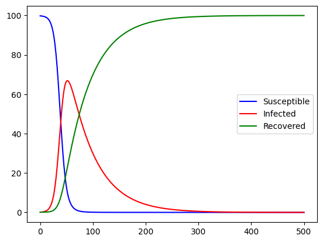

```python
pop = 100
I0 = 0.1
R0 = 0.1
S0 = pop - I0 - R0
b = 0.2
g = 0.02
t = np.linspace(0, 500, 500)

y0 = S0, I0, R0

data = odeint(model, y0, t, args=(pop, b, g))

data = pd.DataFrame(data, index = t, columns=['Susceptible', 'Infected', 'Recovered'])
sns.lineplot(data=data, dashes = False, palette=['b', 'r', 'g'])
```

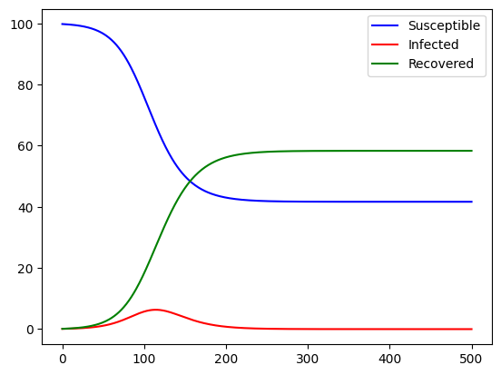

```python
pop = 100
I0 = 0.1
R0 = 0.1
S0 = pop - I0 - R0
b = 0.15
g = 0.1
t = np.linspace(0, 500, 500)

y0 = S0, I0, R0

data = odeint(model, y0, t, args=(pop, b, g))

data = pd.DataFrame(data, index = t, columns=['Susceptible', 'Infected', 'Recovered'])
sns.lineplot(data=data, dashes = False, palette=['b', 'r', 'g'])
```

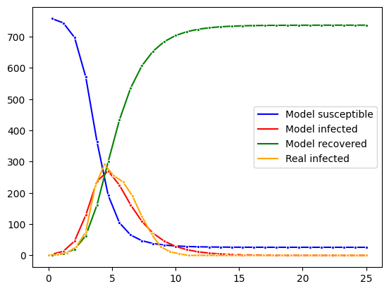

```python
pop = 763
I0 = 1 / pop
R0 = 0
S0 = pop - I0 - R0
b = 2.1
g = 0.6
t = np.linspace(0, 25, 35)
t1 = np.linspace(-5, 25, 35)

real = [1,3,8,28,75,221,291,255,235,190,125,70,28,12,5,0,0,0,0,0,0,0,0,0,0,0,0,0,0,0,0,0,0,0,0]
real = pd.DataFrame(real, index = t, columns=['Real infected'])

y0 = S0, I0, R0

data = odeint(model, y0, t1, args=(pop, b, g))
data = pd.DataFrame(data, index = t1, columns=['Model susceptible', 'Model infected', 'Model recovered'])
data = data[data.index > 0]

sns.lineplot(data=data, marker = '.', dashes = False, palette=['b', 'r', 'g'])
sns.lineplot(data=real, marker = '.', palette=['orange'])
```

# Vaccination strategies

#### 1. Slowing the spread

A vaccine is introduced that aims to reduce the speed at which the disease spreads from infected individuals to susceptible individuals. All boys receive the vaccine. The vaccine reduces the transmission value of the disease by 25%. In the model, this is achieved by multiplying the b value by 0.75. We expect this change to lower the peak and spread out the number of cases over a longer period of time. Both of these changes should make it easier for supporting health care providers to aid the boys recovery.

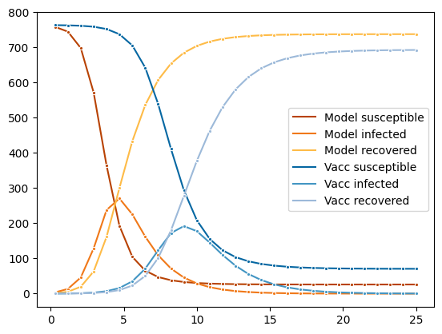

```python
vacc_b = b * 0.75

vacc = odeint(model, y0, t1, args=(pop, vacc_b , g))
vacc = pd.DataFrame(vacc, index = t1, columns=['Vacc susceptible', 'Vacc infected', 'Vacc recovered'])
vacc = vacc[vacc.index > 0]

palette_model = sns.color_palette("YlOrBr_r",4)
palette_vacc = sns.color_palette("PuBu_r", 4)

sns.lineplot(data=data, marker = '.', dashes = False, palette=palette_model)
sns.lineplot(data=vacc, marker = '.', dashes = False, palette=palette_vacc)
```

##### Results

Compared the model with no vaccination strategy, the results show a decrease in the height of the peak. We also observe a small increase in spread over time as well as a longer delay before cases reach peak height. The decrease in height of the peak is quite significant and we also observe a larger spread of cases of time. Furthermore, we observe the rate of new infections be decreased, as the slope is less steep.

### 2.0 Recovery

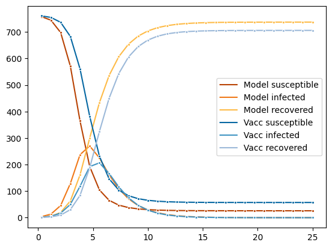

```python
vacc_g = g * 1.25

vacc2 = odeint(model, y0, t1, args=(pop, b , vacc_g))
vacc2 = pd.DataFrame(vacc2, index = t1, columns=['Vacc susceptible', 'Vacc infected', 'Vacc recovered'])
vacc2 = vacc2[vacc2.index > 0]

palette_model = sns.color_palette("YlOrBr_r",4)
palette_vacc = sns.color_palette("PuBu_r", 4)

sns.lineplot(data=data, marker = '.', dashes = False, palette=palette_model)
sns.lineplot(data=vacc2, marker = '.', dashes = False, palette=palette_vacc)
```

##### Results

The results show a small decrease in the peak number of cases. There is no significant delay or increase in spread of the infections. There is also no real increase in rate of recovery from infection.

### Comparison and conclusion

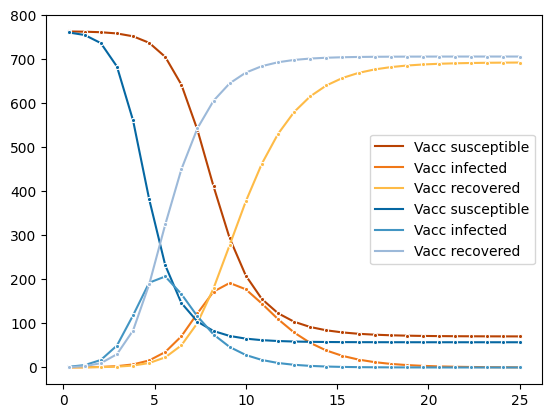

```python
sns.lineplot(data=vacc, marker = '.', dashes = False, palette=palette_model)
sns.lineplot(data=vacc2, marker = '.', dashes = False, palette=palette_vacc)
```

```python
#print(vacc2["Vacc infected"].to_numpy())
#print(vacc["Vacc infected"].to_numpy())
```